# crop-recommender-with-ensemble-modeling

```python
# This Python 3 environment comes with many helpful analytics libraries installed
# It is defined by the kaggle/python Docker image: https://github.com/kaggle/docker-python
# For example, here's several helpful packages to load

import numpy as np # linear algebra
import pandas as pd # data processing, CSV file I/O (e.g. pd.read_csv)

# Input data files are available in the read-only "../input/" directory
# For example, running this (by clicking run or pressing Shift+Enter) will list all files under the input directory

import os
for dirname, _, filenames in os.walk('/kaggle/input'):
    for filename in filenames:
        print(os.path.join(dirname, filename))

# You can write up to 20GB to the current directory (/kaggle/working/) that gets preserved as output when you create a version using "Save & Run All"
# You can also write temporary files to /kaggle/temp/, but they won't be saved outside of the current session
```

```
/kaggle/input/crop-recommender-dataset-with-soil-nutrients/dataset.csv
```

In this notebook I tried to test six machine learning models against each other and combine the top-3 models in two ensemble models, stacking model and majority vote based model.

The ensemble models failed to compete with the top-3 simple models.

I compare between the performence of the models by learning curves and ROC-curve.

The "Crop Recommender Dataset with Soil Nutrients" Dataset trying to improve crop yield by recommending the right crop to grow.

The soil nutrient database provides standardized information about the crop nutrient values in India.

Tabel of content:

Chapter 1: Introduction

Chapter 2: Data Preprocessing

Chapter 3: Normalized data

Chapter 4: Exploratory Data Analysis (EDA)

Chapter 5: Modelling

Chapter 6: Results

# 1. Introduction

## Libraries and Utilities

```python
import numpy as np
import pandas as pd
from sklearn.model_selection import train_test_split
import matplotlib.pyplot as plt
import seaborn as sns
from scipy import stats
from sklearn.manifold import TSNE
from sklearn.preprocessing import MinMaxScaler
from sklearn.cluster import KMeans
```

## Data Loading

```python
data = pd.read_csv('../input/crop-recommender-dataset-with-soil-nutrients/dataset.csv')
```

## Reading data

```python
# check the numbers of samples and features
data.shape
```

```
(620, 12)
```

```python
# display the first five rows of the dataset.
data.head()
```

|  | N | P | K | ph | EC | S | Cu | Fe | Mn | Zn | B | label |
| --- | --- | --- | --- | --- | --- | --- | --- | --- | --- | --- | --- | --- |
| 0 | 143 | 69 | 217 | 5.900 | 0.580 | 0.230 | 10.200 | 116.350 | 59.960 | 54.850 | 21.290 | pomegranate |
| 1 | 170 | 36 | 216 | 5.900 | 0.150 | 0.280 | 15.690 | 114.200 | 56.870 | 31.280 | 28.620 | pomegranate |
| 2 | 158 | 66 | 219 | 6.800 | 0.340 | 0.200 | 15.290 | 65.870 | 51.810 | 57.120 | 27.590 | pomegranate |
| 3 | 133 | 45 | 207 | 6.400 | 0.940 | 0.210 | 8.480 | 103.100 | 43.810 | 68.500 | 47.290 | pomegranate |
| 4 | 132 | 48 | 218 | 6.700 | 0.540 | 0.190 | 5.590 | 63.400 | 56.400 | 46.710 | 31.040 | pomegranate |

```python
# display the last five rows of the dataset.
data.tail()
```

|  | N | P | K | ph | EC | S | Cu | Fe | Mn | Zn | B | label |
| --- | --- | --- | --- | --- | --- | --- | --- | --- | --- | --- | --- | --- |
| 615 | 41 | 23 | 135 | 5.000 | 1.670 | 0.107 | 26.000 | 39.200 | 206.890 | 31.090 | 20.640 | potato |
| 616 | 49 | 45 | 90 | 5.800 | 1.980 | 0.092 | 19.000 | 40.200 | 91.120 | 32.680 | 14.910 | potato |
| 617 | 131 | 24 | 121 | 4.900 | 2.240 | 0.088 | 22.000 | 40.000 | 94.340 | 24.930 | 23.740 | potato |
| 618 | 131 | 55 | 130 | 5.300 | 2.480 | 0.090 | 15.000 | 41.000 | 92.580 | 45.730 | 21.480 | potato |
| 619 | 129 | 34 | 160 | 4.800 | 1.080 | 0.089 | 25.000 | 39.000 | 259.930 | 33.490 | 14.160 | potato |

```python
# display the labels
data['label'].unique()
```

```
array(['pomegranate', 'mango', 'grapes', 'mulberry', 'ragi', 'potato'],
      dtype=object)
```

The label contain 6 unique values.

```python
data.info()
```

```
<class 'pandas.core.frame.DataFrame'>
RangeIndex: 620 entries, 0 to 619
Data columns (total 12 columns):
 #   Column  Non-Null Count  Dtype
---  ------  --------------  -----
 0   N       620 non-null    int64
 1   P       620 non-null    int64
 2   K       620 non-null    int64
 3   ph      620 non-null    float64
 4   EC      620 non-null    float64
 5   S       620 non-null    float64
 6   Cu      620 non-null    float64
 7   Fe      620 non-null    float64
 8   Mn      620 non-null    float64
 9   Zn      620 non-null    float64
 10  B       620 non-null    float64
 11  label   620 non-null    object
dtypes: float64(8), int64(3), object(1)
memory usage: 58.2+ KB
```

```python
# display the features
data.columns
```

```
Index(['N', 'P', 'K', 'ph', 'EC', 'S', 'Cu', 'Fe', 'Mn', 'Zn', 'B', 'label'], dtype='object')
```

```python
# a small correction, for those suffering from O.C.D
data.rename(columns = {'ph':'pH'}, inplace = True)
data.columns
```

```
Index(['N', 'P', 'K', 'pH', 'EC', 'S', 'Cu', 'Fe', 'Mn', 'Zn', 'B', 'label'], dtype='object')
```

```python
data.dtypes
```

```
N          int64
P          int64
K          int64
pH       float64
EC       float64
S        float64
Cu       float64
Fe       float64
Mn       float64
Zn       float64
B        float64
label     object
dtype: object
```

```python
data.describe()
```

|  | N | P | K | pH | EC | S | Cu | Fe | Mn | Zn | B |
| --- | --- | --- | --- | --- | --- | --- | --- | --- | --- | --- | --- |
| count | 620.000 | 620.000 | 620.000 | 620.000 | 620.000 | 620.000 | 620.000 | 620.000 | 620.000 | 620.000 | 620.000 |
| mean | 135.702 | 52.508 | 161.402 | 6.106 | 0.885 | 0.484 | 17.315 | 117.213 | 219.906 | 34.341 | 28.751 |
| std | 31.808 | 24.674 | 81.286 | 0.694 | 0.637 | 5.775 | 6.441 | 62.775 | 341.999 | 11.544 | 19.636 |
| min | 30.000 | 10.000 | 51.000 | 4.500 | 0.010 | 0.011 | 0.180 | 3.810 | 20.580 | 17.990 | 1.020 |
| 25% | 116.000 | 30.000 | 89.000 | 5.700 | 0.297 | 0.086 | 12.592 | 68.312 | 58.785 | 24.727 | 13.442 |
| 50% | 138.000 | 54.000 | 157.500 | 6.100 | 0.780 | 0.168 | 16.910 | 108.245 | 73.580 | 31.425 | 23.225 |
| 75% | 160.000 | 75.000 | 206.000 | 6.500 | 1.390 | 0.240 | 21.102 | 155.620 | 163.665 | 43.543 | 42.767 |
| max | 198.000 | 100.000 | 369.000 | 8.000 | 2.480 | 113.200 | 35.000 | 276.720 | 1572.540 | 70.000 | 74.560 |

# 2. Data Preprocessing

## Check for missing data

```python
data.isnull().sum()
```

```
N        0
P        0
K        0
pH       0
EC       0
S        0
Cu       0
Fe       0
Mn       0
Zn       0
B        0
label    0
dtype: int64
```

No missing data.

## Check for imbalanced data

```python
data['label'].value_counts()
```

```
pomegranate    104
mango          104
grapes         104
mulberry       104
ragi           104
potato         100
Name: label, dtype: int64
```

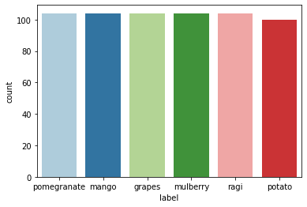

```python
g = sns.countplot(x=data['label'], palette='Paired')
g = g.set_xticklabels(['pomegranate', 'mango', 'grapes', 'mulberry', 'ragi', 'potato'])
```

The data is balanced.

## Splitting to train and test sets

```python
X = data.iloc[:,:11]
label = data['label']

X_train, X_test, y_train, y_test = train_test_split(X, label, train_size=0.8, random_state=42, stratify=label)
```

```python
# balanced data, also after spliting to train and test
y_train.value_counts()
```

```
mango          84
pomegranate    83
mulberry       83
ragi           83
grapes         83
potato         80
Name: label, dtype: int64
```

```python
# defining variables for future use
features = X_train.columns
train = pd.concat([X_train, y_train], axis=1)
```

## Outlier detection

```python
from collections import Counter

def detect_outliers(df, n, features):
    outlier_indices = []

    for col in features:
        Q1 = np.percentile(df[col], 25)
        Q3 = np.percentile(df[col], 75)
        IQR = Q3 - Q1

        outlier_step = 1.5 * IQR

        outlier_list_col = df[(df[col] < Q1 - outlier_step) | (df[col] > Q3 + outlier_step )].index

        outlier_indices.extend(outlier_list_col)

    outlier_indices_counter = Counter(outlier_indices)
    multiple_outliers = [ k for k, v in outlier_indices_counter.items() if v > n]

    return multiple_outliers, outlier_indices
```

```python
outliers_to_drop, outliers = detect_outliers(X_train, 2, features)
print(f"{len(outliers)} samples contain outliers, {len(outliers_to_drop)} of them are outliers in more then two features.")
```

```
94 samples contain outliers, 0 of them are outliers in more then two features.
```

"Detect outliers" function indicates thet we don't have any outliers to drop.

In order to confirm it, we will display a box plot for each feature:

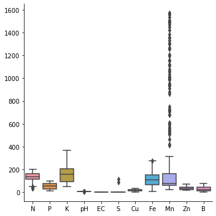

```python
#X_train[X_train.columns].boxplot()
sns.catplot(data=X_train ,kind="box")
```

Focusing on Mn and S, which have the most significant outliers samples.

### Checking Manganese Outliers

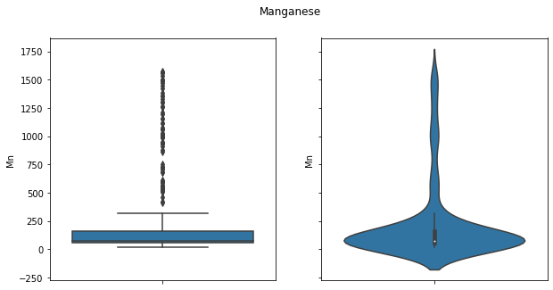

```python
fig, axs = plt.subplots(1,2, figsize=(10, 5), sharey=True)
fig.suptitle('Manganese')
sns.boxplot(ax=axs[0], y='Mn',  data=X_train)
sns.violinplot(ax=axs[1], y='Mn',  data=X_train)
```

Unnegligible number of outliers are obtain in box plot for Manganese.

The distribution shown in violin plot is normal for most of the data and uniform for outlier samples.

Therefore I decide to keep all samples.

```python
feat_without_Mn = features.drop(['Mn'])
```

```python
outliers_to_drop, outliers = detect_outliers(X_train, 2, feat_without_Mn)
print(f"{len(outliers)} samples contain outliers, {len(outliers_to_drop)} of them are outliers in more then two features.")
```

```
24 samples contain outliers, 0 of them are outliers in more then two features.
```

### Checking Sulfur Outliers

The two outlier samples of Sulfur (S) are extremely far from IQR.

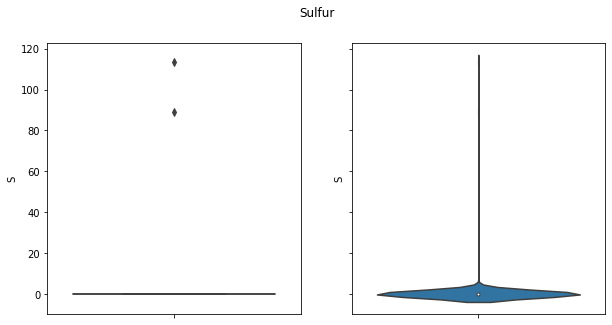

```python
fig, ax = plt.subplots(1,2, figsize=(10, 5), sharey=True)
fig.suptitle('Sulfur')
sns.boxplot(ax=ax[0], y='S',  data=X_train)
sns.violinplot(ax=ax[1], y='S',  data=X_train)
```

The decaying distribution for outlier samples, indicates those samples are outliers.

### Dropping Outliers

```python
# finding Sulfur outliers indecies
outliers_to_drop, S_outliers_indecies = detect_outliers(X_train, 1, 'S')
S_outliers_indecies
```

```
[414, 415]
```

```python
# drop outliers
X_train = X_train.drop(S_outliers_indecies, axis=0).reset_index(drop=True)
y_train = y_train.drop(S_outliers_indecies, axis=0).reset_index(drop=True)
train = train.drop(S_outliers_indecies, axis=0).reset_index(drop=True)
```

# 3. Normalized data

## Skewness Correction

```python
# check skewness for all numerical features
skewed_feats = X_train.apply(lambda x: x.skew()).sort_values(ascending=False)
print("\nSkew in numerical features (origin X_train): \n")
skewness = pd.DataFrame({'Skew' :skewed_feats})
pd.set_option('display.float_format', lambda x: '{:.3f}'.format(x))
skewness.head(11)
```

```
Skew in numerical features (origin X_train):
```

|  | Skew |
| --- | --- |
| Mn | 2.523 |
| Zn | 0.733 |
| Fe | 0.702 |
| K | 0.680 |
| EC | 0.670 |
| B | 0.645 |
| Cu | 0.449 |
| pH | -0.011 |
| S | -0.055 |
| P | -0.072 |
| N | -0.690 |

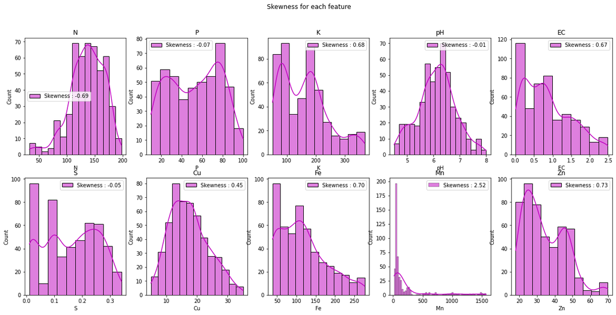

```python
features = X_train.columns


fig, axs = plt.subplots(2, 5, figsize=(20, 9))
fig.suptitle('Skewness for each feature')
for i, ax in enumerate(axs.ravel()):
    g = sns.histplot(X_train.iloc[:,i], color='m', label='Skewness : %.2f'%(X_train.iloc[:,i].skew()), ax=ax, kde=True)
    g = g.legend(loc='best')
    ax.set_title(features[i])
```

Apply log to feature with high skewness (Mn), to reduce skewness distribution:

```python
# Skewness correction (origin X_train)

X_train['Mn']= stats.boxcox(X_train['Mn'], lmbda=0.001)
X_train['Zn']= stats.boxcox(X_train['Zn'], lmbda=0.5)
X_train['Fe']= stats.boxcox(X_train['Fe'], lmbda=0.5)
X_train['K']= stats.boxcox(X_train['K'], lmbda=0.5)
X_train['EC']= stats.boxcox(X_train['EC'], lmbda=0.5)
```

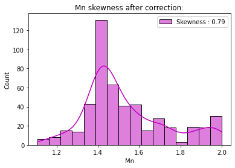

```python
X_train['Mn'] = X_train['Mn'].map(lambda i: np.log(i) if i> 0 else 0)

g = sns.histplot(X_train['Mn'], color='m', label='Skewness : %.2f'%(X_train['Mn'].skew()), kde=True)
g.legend(loc='best')
g.set_title("Mn skewness after correction:")
```

## Scaling

```python
# Min-Max Normalization

scaler = MinMaxScaler()

X_train_scaled = pd.DataFrame(scaler.fit_transform(X_train), columns=X_train.columns, index=X_train.index)
```

# 4. Exploratory Data Analysis (EDA)

## Correlation

### Correlation matrix

correlation between features.

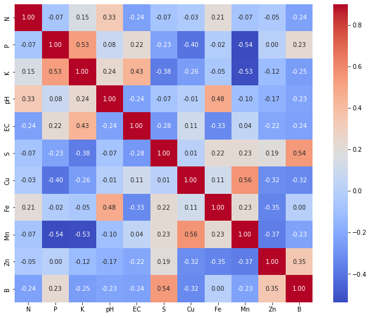

```python
corrmat = X_train.corr()
plt.subplots(figsize=(12,9))
sns.heatmap(corrmat, vmax=0.9, square=True, annot=True, fmt=".2f", cmap = "coolwarm")
```

Correlation map indicates very low correlation between all features, which emphasizes the significance of each individual feature.

It seems to have weak positive correlation between the pairs: Potasium (K) & Phosphorus (P), Sulphur (S) & Boron (B) and Cooper (Cu) & Manganese (Mn).

A weak negative correlation is received between Manganese (Mn) & Phosphorus (P).

### Pair plot

correlation between features, another way for looking.

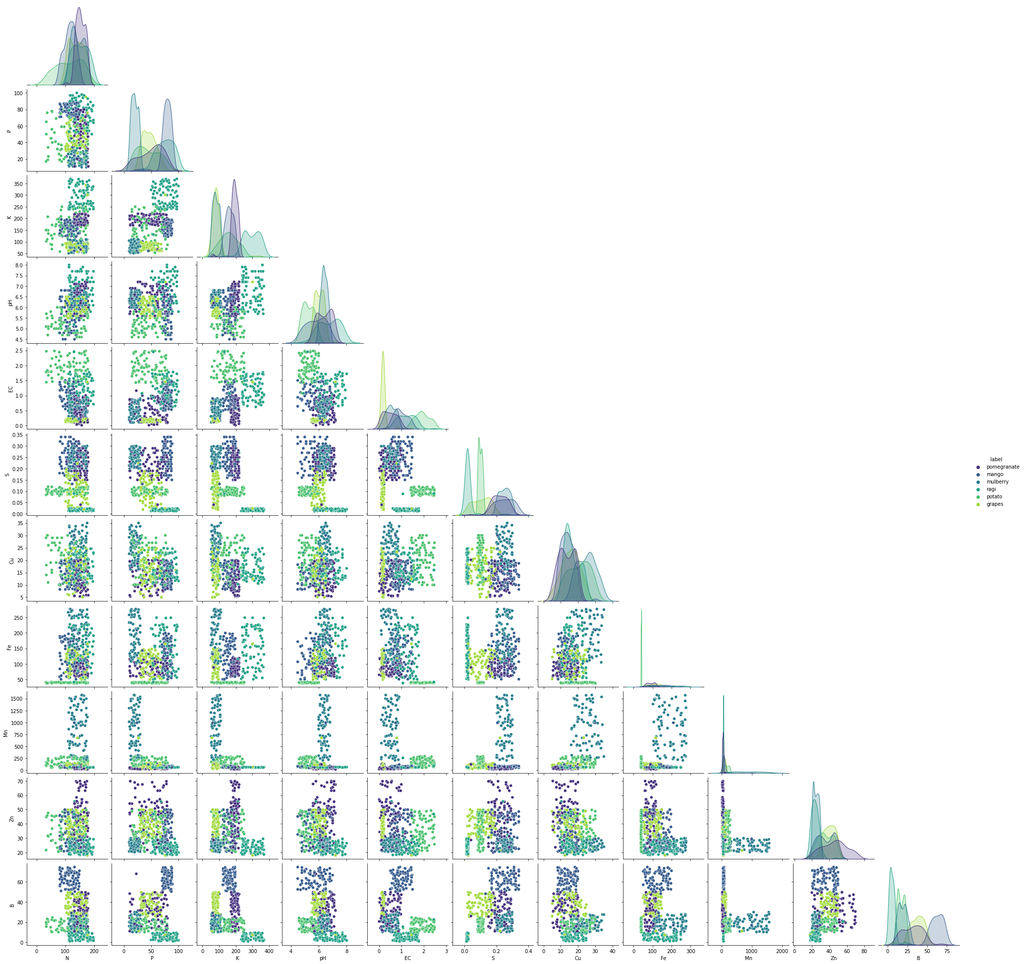

```python
sns.pairplot(train, hue='label', palette='viridis', corner=True)
```

The pairplot garph indicate a linear division.

### Correlation matrix

correlation with labels.

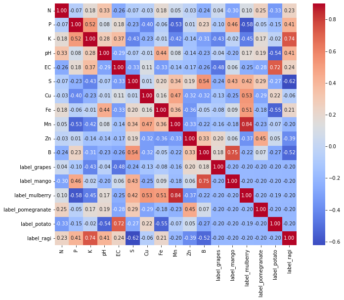

```python
train = pd.get_dummies(train, drop_first=False, columns=['label'])

corrmat = train.corr()
plt.subplots(figsize=(12,9))
sns.heatmap(corrmat, vmax=0.9, square=True, annot=True, fmt=".2f", cmap = "coolwarm")
```

Mango is associative with high Boron (B).

Mulberry is associative with high *Manganese* (Mn).

Ragi is associative with high Potassium (K).

Potato is associative with high electrical conducativity (EC).

## Visualizstion of data by label (t-SNE)

Dimention reduction into 2-D by t-SNE

```python
tsne = TSNE(n_components=2, learning_rate='auto', init='random').fit_transform(X_train_scaled)
tsne.shape
```

```
(494, 2)
```

```python
X_train.shape
```

```
(494, 11)
```

[output not shown]

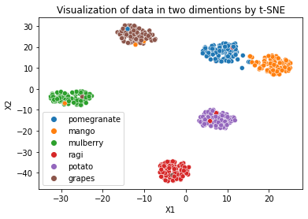

```python
g = sns.scatterplot(data=tsne, x=tsne[:,0], y=tsne[:,1], hue=y_train.values)
g.set(xlabel='X1', ylabel='X2', title='Visualization of data in two dimentions by t-SNE')
```

There is a good separation between the classes.

## Unsupervised learning

```python
kmeans = KMeans(n_clusters=6, random_state=0).fit(X_train_scaled)
```

[output not shown]

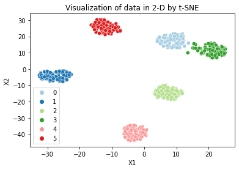

```python
g = sns.scatterplot(data=tsne, x=tsne[:,0], y=tsne[:,1], hue=kmeans.labels_, palette="Paired")
g.set(xlabel='X1', ylabel='X2', title='Visualization of data in 2-D by t-SNE')
```

High similarity between unsupervised clustering (by K-means) and classification as accepted by true label.

Each class represents different group, non of the labels should be join.

# 5. Modelling

## Libraries and Utilities

```python
from sklearn.pipeline import make_pipeline

from sklearn.linear_model import LogisticRegression
from sklearn.svm import SVC
from sklearn.neighbors import KNeighborsClassifier
from sklearn.ensemble import RandomForestClassifier, AdaBoostClassifier, StackingClassifier, VotingClassifier
from sklearn.tree import DecisionTreeClassifier
from sklearn.preprocessing import LabelEncoder
from xgboost import XGBClassifier

from sklearn.model_selection import GridSearchCV, learning_curve
from sklearn.metrics import f1_score, roc_curve, auc
from sklearn.preprocessing import label_binarize

from sklearn.metrics import ConfusionMatrixDisplay
```

## Simple modeling

I compared six popular classifiers and evaluate the mean accuracy of each of them by a stratified kfold cross validation procedure.

- Random Forest
- AdaBoost
- SVM
- KNN
- Logistic regression
- Gradient Boosting

### Hyperparameter tunning

Choosing best estimators for models

```python
# adjusting the format of the label to xgboost model

le = LabelEncoder()
y_train_gb = le.fit_transform(y_train)
```

```python
# choosing best estimators for Random Forest model:
param_grid = {'max_depth': [2, 3, 4, 5, 6, 10, 100, 300], 'n_estimators':[100, 500, 1000]}  # what about n_estimators??
rf_model = GridSearchCV(RandomForestClassifier(random_state=42), param_grid)
rf_model.fit(X_train, y_train)
print(f"Best estimators for Random Forest: {rf_model.best_estimator_}")

# choosing best estimators for AdaBoost model:
param_grid = {'n_estimators': [10, 20, 50, 100], 'learning_rate': [0.1, 0.2, 0.5, 0.7, 0.8, 1]}
ada_model = GridSearchCV(AdaBoostClassifier(random_state=42), param_grid)
ada_model.fit(X_train, y_train)
print(f"Best estimators for AdaBoost: {ada_model.best_estimator_}")

# choosing best estimators for svm model:
param_grid = {'kernel': ['linear','poly','rbf'], 'C': [0.001, 0.01, 0.1, 1, 10],
                  'gamma': [1, 0.1]}
svm_model = GridSearchCV(SVC(class_weight='balanced', random_state=42), param_grid)
svm_model.fit(X_train_scaled, y_train)
print(f"Best estimators for SVM: {svm_model.best_estimator_}")

# choosing best estimators for KNN model:
param_grid = {'n_neighbors': list(range(3, 16, 2))}
knn_model = GridSearchCV(KNeighborsClassifier(), param_grid)
knn_model.fit(X_train_scaled, y_train)
print(f"Best estimators for K-Nearest Neighbor: {knn_model.best_estimator_}")

# choosing best estimators for Gradient Boosting model:
param_grid = {'n_estimators': [10, 20, 50, 100, 300, 500], 'learning_rate': [0.1, 0.8, 1], 'max_depth' : [1, 2, 3, 5]}
gb_model = GridSearchCV(XGBClassifier(random_state=42), param_grid)
gb_model.fit(X_train, y_train_gb)
print(f"Best estimators for Gradient Boosting: {gb_model.best_estimator_}")
```

```
Best estimators for Random Forest: RandomForestClassifier(max_depth=2, random_state=42)
Best estimators for AdaBoost: AdaBoostClassifier(learning_rate=0.5, n_estimators=100, random_state=42)
Best estimators for SVM: SVC(C=0.1, class_weight='balanced', gamma=1, kernel='poly', random_state=42)
Best estimators for K-Nearest Neighbor: KNeighborsClassifier(n_neighbors=7)
Best estimators for Gradient Boosting: XGBClassifier(base_score=0.5, booster='gbtree', callbacks=None,
              colsample_bylevel=1, colsample_bynode=1, colsample_bytree=1,
              early_stopping_rounds=None, enable_categorical=False,
              eval_metric=None, gamma=0, gpu_id=-1, grow_policy='depthwise',
              importance_type=None, interaction_constraints='',
              learning_rate=0.1, max_bin=256, max_cat_to_onehot=4,
              max_delta_step=0, max_depth=1, max_leaves=0, min_child_weight=1,
              missing=nan, monotone_constraints='()', n_estimators=50, n_jobs=0,
              num_parallel_tree=1, objective='multi:softprob', predictor='auto',
              random_state=42, reg_alpha=0, ...)
```

### Creating the simple models

```python
rf = RandomForestClassifier(max_depth=2, random_state=42)
ada = AdaBoostClassifier(learning_rate=0.5, n_estimators=100, random_state=42)
svm = SVC(kernel='poly', C=0.1, class_weight='balanced', gamma=1, probability=True, random_state=42)
knn = KNeighborsClassifier(n_neighbors=7)
log = LogisticRegression(max_iter=400, random_state=42)
gb = XGBClassifier(n_estimators=50, learning_rate=0.1, max_depth=1, random_state=42)
```

### Learning curves

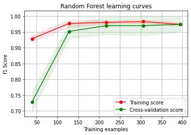

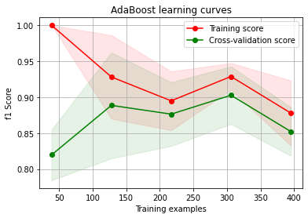

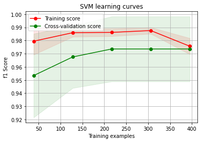

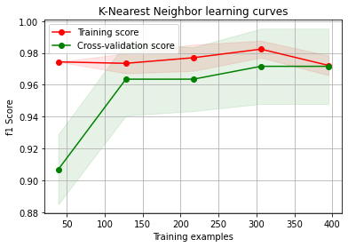

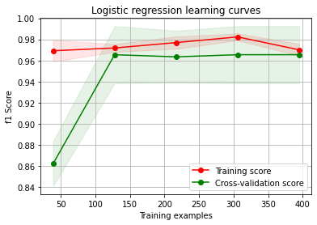

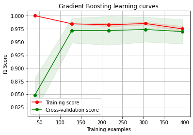

```python
def plot_learning_curve(estimator, title, X, y, ylim=None, cv=None, scoring='f1_micro',
                        n_jobs=-1, train_sizes=np.linspace(.1, 1.0, 5)):
    """Generate a simple plot of the test and training learning curve"""
    plt.figure()
    plt.title(title)
    if ylim is not None:
        plt.ylim(*ylim)
    plt.xlabel("Training examples")
    plt.ylabel("f1 Score")
    train_sizes, train_scores, test_scores = learning_curve(
        estimator, X, y, cv=cv, n_jobs=n_jobs, train_sizes=train_sizes, scoring='f1_micro')
    train_scores_mean = np.mean(train_scores, axis=1)
    train_scores_std = np.std(train_scores, axis=1)
    test_scores_mean = np.mean(test_scores, axis=1)
    test_scores_std = np.std(test_scores, axis=1)
    plt.grid()

    plt.fill_between(train_sizes, train_scores_mean - train_scores_std,
                     train_scores_mean + train_scores_std, alpha=0.1,
                     color="r")
    plt.fill_between(train_sizes, test_scores_mean - test_scores_std,
                     test_scores_mean + test_scores_std, alpha=0.1, color="g")
    plt.plot(train_sizes, train_scores_mean, 'o-', color="r",
             label="Training score")
    plt.plot(train_sizes, test_scores_mean, 'o-', color="g",
             label="Cross-validation score")

    plt.legend(loc="best")
    return plt, test_scores_mean, test_scores_std


g, rf_mean, rf_std = plot_learning_curve(rf,"Random Forest learning curves",X_train,y_train,cv=5)
g, ada_mean, ada_std = plot_learning_curve(ada,"AdaBoost learning curves",X_train,y_train,cv=5)
g, svm_mean, svm_std = plot_learning_curve(svm,"SVM learning curves",X_train_scaled,y_train,cv=5)
g, knn_mean, knn_std = plot_learning_curve(knn,"K-Nearest Neighbor learning curves",X_train_scaled,y_train,cv=5)
g, log_mean, log_std = plot_learning_curve(log,"Logistic regression learning curves",X_train_scaled,y_train,cv=5)
g, gb_mean, gb_std = plot_learning_curve(gb,"Gradient Boosting learning curves",X_train,y_train_gb,cv=5)
```

All classifiers generalize the prediction since the training and cross-validation curves are close together.

Adding more examples will not perform much better.

```python
# printing accuracy and std of validation for each model
print(f"\nRandom Forest score: {rf_mean.mean():.2f} ({rf_std.mean():.2f})\n")
print(f"\nAdaBoost score: {ada_mean.mean():.2f} ({ada_std.mean():.2f})\n")
print(f"\nSVM score: {svm_mean.mean():.2f} ({svm_std.mean():.2f})\n")
print(f"\nK-Nearest Neighbor score: {knn_mean.mean():.2f} ({knn_std.mean():.2f})\n")
print(f"\nLogistic Regression score: {log_mean.mean():.2f} ({log_std.mean():.2f})\n")
print(f"\nGradient Boosting score: {gb_mean.mean():.2f} ({gb_std.mean():.2f})\n")
```

```
Random Forest score: 0.92 (0.03)


AdaBoost score: 0.87 (0.05)


SVM score: 0.97 (0.03)


K-Nearest Neighbor score: 0.96 (0.02)


Logistic Regression score: 0.94 (0.03)


Gradient Boosting score: 0.95 (0.03)
```

## Ensemble models

Combining the top-3 models in an attempt to get a more accurate prediction model.

The ensemble model will be done in two methods, stacking model and majority vote.

```python
estimators = [('svm_stck', make_pipeline(scaler, SVC(kernel='linear', C=1, class_weight='balanced', gamma=1, probability=True, random_state=42))),
              ('knn_stck', make_pipeline(scaler, KNeighborsClassifier(n_neighbors=3))),
              ('gb_stck', XGBClassifier(max_depth=1, n_estimators=50, random_state=42, learning_rate=0.1))]


X_train80, X_val, y_train80, y_val = train_test_split(X_train, y_train, train_size=0.8, random_state=42, stratify=y_train)
```

### Stacking model

Stacking the predictions of top-3 models and fit them in another model (final estimator).

```python
final_estimator = LogisticRegression(max_iter=400)

stck = StackingClassifier(estimators=estimators, final_estimator=final_estimator, stack_method='predict')

accuracy = stck.fit(X_train80, y_train80).score(X_val, y_val)
print(f"\nStacking model accuracy: {accuracy:.2f}\n")

stck_pred = stck.predict(X_val)
f1 = f1_score(y_val, stck_pred, average='macro')
print(f"\nStacking model f1 score: {f1:.2f}\n")
```

```
Stacking model accuracy: 0.92


Stacking model f1 score: 0.92
```

The score obtained is lower than the score obtained for most of the simple models, therefore this model will not be used later.

### A majority vote based model

```python
vote = VotingClassifier(estimators=estimators, voting='soft')
accuracy = vote.fit(X_train80, y_train80).score(X_val, y_val)
print(f"\nMajority vote accuracy: {accuracy:.2f}\n")

vote_pred = vote.predict(X_val)
f1 = f1_score(y_val, vote_pred, average='macro')
print(f"\nMajority vote model f1 score: {f1:.2f}\n")
```

```
Majority vote accuracy: 0.93


Majority vote model f1 score: 0.93
```

The score obtained is lower than the score obtained for most of the simple models, therefore this model will not be used later.

## ROC-Curves

Plotting ROC-curves and AOC for comparison in order to choose the best model.

```python
X_train_roc, X_val_roc, y_train_roc, y_val_roc = train_test_split(X_train, y_train, train_size=0.8, random_state=42, stratify=y_train)
```

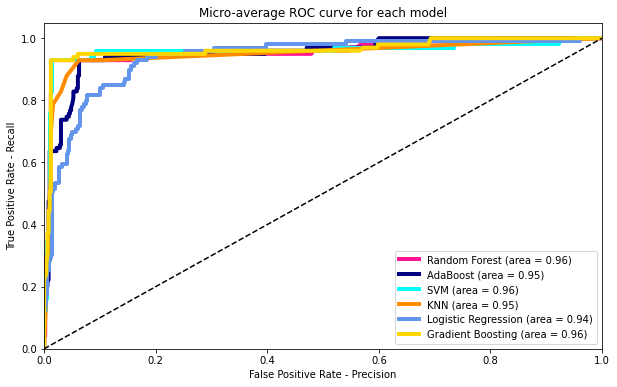

```python
# micro-average ROC-curves

list_of_models = [rf, ada, svm, knn, log, gb]
names_of_models = ["Random Forest", "AdaBoost", "SVM", "KNN", "Logistic Regression", "Gradient Boosting"]
colors = ['deeppink', 'navy', 'aqua', 'darkorange', 'cornflowerblue', 'gold']


def roc_for_each_model_micro(y_test, X_test, list_of_models, names_of_models, colors, X_train, y_train):
    y_test_num = y_test.map({'pomegranate':0, 'mango':1, 'grapes':2, 'mulberry':3, 'ragi':4, 'potato':5})
    y_train_num = y_train.map({'pomegranate':0, 'mango':1, 'grapes':2, 'mulberry':3, 'ragi':4, 'potato':5})
    y_test_bin = label_binarize(y_test_num, classes=np.arange(6))

    plt.figure(figsize=(10,6))

    for i, (model, name, color) in enumerate(zip(list_of_models, names_of_models, colors)):
        if model in [svm, knn, log]:
            X_train = pd.DataFrame(scaler.transform(X_train), columns=X_train.columns, index=X_train.index)
            X_test = pd.DataFrame(scaler.transform(X_test), columns=X_test.columns, index=X_test.index)

        y_prob = model.fit(X_train, y_train_num).predict_proba(X_test)
        fpr, tpr, _ = roc_curve(y_test_bin.ravel(), y_prob.ravel())
        roc_auc = auc(fpr, tpr)

        plt.plot(
              fpr,
              tpr,
              label=f"{name} (area = {roc_auc:.2f})",
              color=color,
              linestyle="-",
              linewidth=4,
            )
    plt.plot([0, 1], [0, 1], "k--")
    plt.xlim([0.0, 1.0])
    plt.ylim([0.0, 1.05])
    plt.xlabel("False Positive Rate - Precision")
    plt.ylabel("True Positive Rate - Recall")
    plt.title("Micro-average ROC curve for each model")
    plt.legend(loc="lower right")
    plt.show()

roc_for_each_model_micro(y_val_roc, X_val_roc, list_of_models, names_of_models, colors, X_train_roc, y_train_roc)
```

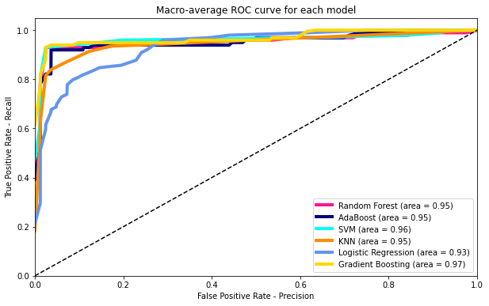

```python
# macro-average ROC-curves
list_of_models = [rf, ada, svm, knn, log, gb]
names_of_models = ["Random Forest", "AdaBoost", "SVM", "KNN", "Logistic Regression", "Gradient Boosting"]
colors = ['deeppink', 'navy', 'aqua', 'darkorange', 'cornflowerblue', 'gold']

def roc_for_each_model_macro(y_test, X_test, list_of_models, names_of_models, colors, X_train, y_train):
    y_test_num = y_test.map({'pomegranate':0, 'mango':1, 'grapes':2, 'mulberry':3, 'ragi':4, 'potato':5})
    y_train_num = y_train.map({'pomegranate':0, 'mango':1, 'grapes':2, 'mulberry':3, 'ragi':4, 'potato':5})
    y_test_bin = label_binarize(y_test_num, classes=np.arange(6))

    plt.figure(figsize=(10,6))

    n_classes = len(np.unique(y_train))
    fpr = dict()
    tpr = dict()
    roc_auc = dict()
    for i, (model, name, color) in enumerate(zip(list_of_models, names_of_models, colors)):
        if model in [svm, knn, log]:
            X_train = pd.DataFrame(scaler.transform(X_train), columns=X_train.columns, index=X_train.index)
            X_test = pd.DataFrame(scaler.transform(X_test), columns=X_test.columns, index=X_test.index)

        y_prob = model.fit(X_train, y_train_num).predict_proba(X_test)
        for j in range(n_classes):
            fpr[j], tpr[j], _ = roc_curve(y_test_bin[:, j], y_prob[:, j])
            roc_auc[j] = auc(fpr[j], tpr[j])
        fpr['micro'], tpr['micro'], _ = roc_curve(y_test_bin.ravel(), y_prob.ravel())
        roc_auc['micro'] = auc(fpr['micro'], tpr['micro'])

        # First aggregate all false positive rates
        all_fpr = np.unique(np.concatenate([fpr[i] for i in range(n_classes)]))

        # Then interpolate all ROC curves at this points
        mean_tpr = np.zeros_like(all_fpr)
        for j in range(n_classes):
            mean_tpr += np.interp(all_fpr, fpr[j], tpr[j])

        # Finally average it and compute AUC
        mean_tpr /= n_classes

        fpr["macro"] = all_fpr
        tpr["macro"] = mean_tpr
        roc_auc["macro"] = auc(fpr["macro"], tpr["macro"])

        plt.plot(
              fpr['macro'],
              tpr['macro'],
              label=f"{name} (area = {roc_auc['macro']:.2f})",
              color=color,
              linestyle="-",
              linewidth=4)

    plt.plot([0, 1], [0, 1], "k--")
    plt.xlim([0.0, 1.0])
    plt.ylim([0.0, 1.05])
    plt.xlabel("False Positive Rate - Precision")
    plt.ylabel("True Positive Rate - Recall")
    plt.title("Macro-average ROC curve for each model")
    plt.legend(loc="lower right")
    plt.show()

roc_for_each_model_macro(y_val_roc, X_val_roc, list_of_models, names_of_models, colors, X_train_roc, y_train_roc)
```

However, the other three model, Random Forestm, AdaBoost and Logistic Regression, yield good predictions as well.

# 6. Results

## Preparing test data

In the same way we prepared the training dataset, so we will prepare the **test dataset**: skewness correction and min-max normalization.

```python
# Skewness correction

X_test['Mn']= stats.boxcox(X_test['Mn'], lmbda=0.001)
X_test['Zn']= stats.boxcox(X_test['Zn'], lmbda=0.5)
X_test['Fe']= stats.boxcox(X_test['Fe'], lmbda=0.5)
X_test['K']= stats.boxcox(X_test['K'], lmbda=0.5)
X_test['EC']= stats.boxcox(X_test['EC'], lmbda=0.5)

X_test['Mn'] = X_test['Mn'].map(lambda i: np.log(i) if i> 0 else 0)
```

```python
# Min-Max Normalization

X_test_scaled = pd.DataFrame(scaler.transform(X_test), columns=X_test.columns, index=X_test.index)
```

```python
# adjusting the format of the label to xgboost model

y_test_gb = le.fit_transform(y_test)
```

## ROC - curves on test

Roc- curves on test are calculated for the purpose of obtaining the accuracy of the models, a measure of how much the models provided an accurate and high-quality prediction.

```
Micro-average ROC curve for each model - on TEST:
```

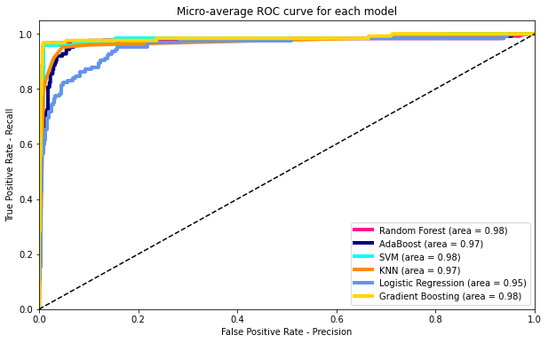

```
Macro-average ROC curve for each model - on TEST:
```

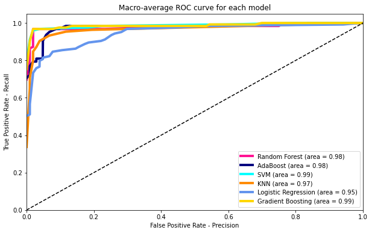

```python
print('Micro-average ROC curve for each model - on TEST:')
roc_for_each_model_micro(y_test, X_test, list_of_models, names_of_models, colors, X_train, y_train)
print('Macro-average ROC curve for each model - on TEST:')
roc_for_each_model_macro(y_test, X_test, list_of_models, names_of_models, colors, X_train, y_train)
```

## Confusion Matrix

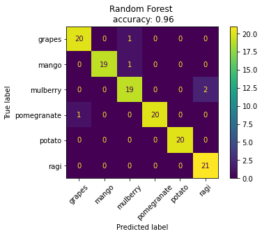

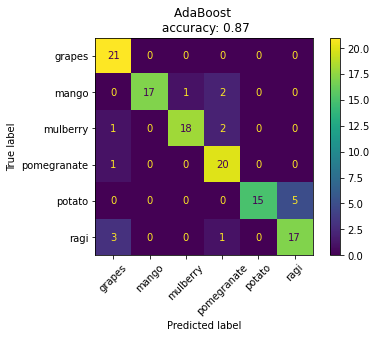

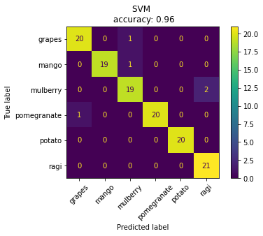

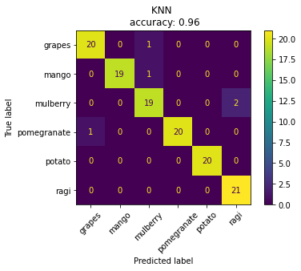

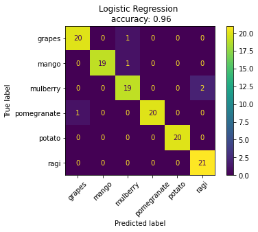

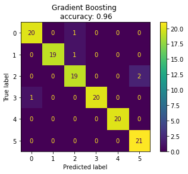

```python
models = [rf, ada, svm, knn, log, gb]
names = ["Random Forest", "AdaBoost", "SVM", "KNN", "Logistic Regression", "Gradient Boosting"]


for model, name in zip(models, names):

    if model in [svm, knn, log]:
        y_pred = model.fit(X_train_scaled, y_train).predict(X_test_scaled)
        fig = ConfusionMatrixDisplay.from_predictions(y_test, y_pred, xticks_rotation=45)
        fig.ax_.set_title(f"{name} \n accuracy: {model.score(X_test_scaled, y_test):.2f}")

    elif model == gb:
        y_pred = model.fit(X_train, y_train_gb).predict(X_test)
        fig = ConfusionMatrixDisplay.from_predictions(y_test_gb, y_pred)
        fig.ax_.set_title(f"{name} \n accuracy: {model.score(X_test, y_test_gb):.2f}")

    else:
        y_pred = model.fit(X_train, y_train).predict(X_test)
        fig = ConfusionMatrixDisplay.from_predictions(y_test, y_pred, xticks_rotation=45)
        fig.ax_.set_title(f"{name} \n accuracy: {model.score(X_test, y_test):.2f}")

plt.show()
```

# Final score

```python
for model, name in zip(models, names):
    if model in [svm, knn, log]:
        score = model.score(X_test_scaled, y_test)
        print(f"\n{name} score: {score:.2f}\n")
    elif model == gb:
        score = model.score(X_test, y_test_gb)
        print(f"\n{name} score: {score:.2f}\n")
    else:
        score = model.score(X_test, y_test)
        print(f"\n{name} score: {score:.2f}\n")
```

```
Random Forest score: 0.96


AdaBoost score: 0.87


SVM score: 0.96


KNN score: 0.96


Logistic Regression score: 0.96


Gradient Boosting score: 0.96
```